# Dplyr, Pipes, and More

Statistical Computing, 36-350

Tuesday September 27, 2022

# Last week: Purrr and a bit of dplyr

- The tidyverse is a collection of packages for common data science tasks
- `purrr` is one such package that provides a consistent family of iteration functions
- `map()`: list in, list out
- `map_dbl()`, `map_lgl()`, `map_chr()`: list in, vector out (of a particular data type)
- `map_dfr()`, `map_dfc()`: list in, data frame out (row-binded or column-binded)
- `dplyr` is another such package that provides functions for data frame computations
- `filter()`: subset rows based on a condition
- `group_by()`: define groups of rows according to a condition
- `summarize()`: apply computations across groups of rows

# Part I

*Motivation: tidyverse, revisited*

# What is the tidyverse?

The tidyverse is a coherent collection of packages in R for data science (and `tidyverse` is itself a actually package that loads all its constituent packages). Packages include:

- **Data wrangling**: `dplyr`, `tidyr`, `readr`
- **Iteration**: `purrr`
- **Visualization**: `ggplot2`

Last week we covered `purrr` and a bit of `dplyr`. This week we’ll do more `dplyr`, and some `tidyr`. (Many of you will learn `ggplot2` in Statistical Graphics 36-315)

Loading the tidyverse so that we can get all this functionality (plus more):

```r
library(tidyverse)
```

# Why the tidyverse?

- Packages have a very consistent API
- Very active developer and user community
- Function names and commands follow a focused **grammar**
- Powerful and fast when working with data frames and lists (matrices, not so much, yet!)
- Pipes (`%>%` operator) allows us to fluidly glue functionality together
- At its best, tidyverse code can be **read like a story** using the pipe operator!

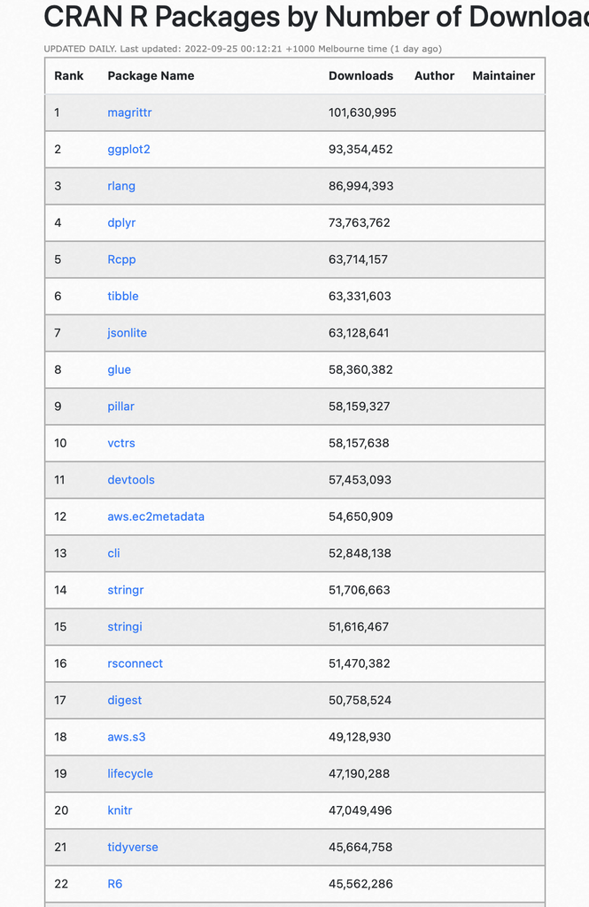

# Data wrangling the tidy way

- Packages `dplyr` and `tidyr` are going to be our main workhorses for data wrangling
- Main structure these packages use is the data frame (or tibble, but we won’t go there)
- Learning pipes `%>%` will facilitate learning the `dplyr` and `tidyr` verbs (functions)
- `dplyr` functions are analogous to SQL counterparts, so learn `dplyr` and get SQL for free!

# Part II

*Mastering the pipe*

# All behold the glorius pipe

- Tidyverse functions are at their best when composed together using the pipe operator
- It looks like this: `%>%`. **Shortcut**: use `ctrl + shift + m` in RStudio
- This operator actually comes from the `magrittr` package (automatically included in `dplyr`)
- **Piping** at its most basic level:

  > Take one return value and automatically feed it in as an input to another function, to form a flow of results
- In unix and related systems, we also have pipes, as in:

```bash
ls -l | grep tidy | wc -l
```

# How to read pipes: single arguments

Passing a single argument through pipes, we interpret something like:

```r
x %>% f %>% g %>% h
```

as `h(g(f(x)))`

**Key takeaway**: in your mind, when you see `%>%`, read this as **“and then”**

# Simple example

We can write `exp(1)` with pipes as `1 %>% exp`, and `log(exp(1))` as `1 %>% exp %>% log`

```r
exp(1)
```

```
## [1] 2.718282
```

```r
1 %>% exp
```

```
## [1] 2.718282
```

```r
1 %>% exp %>% log
```

```
## [1] 1
```

# How to read pipes: multiple arguments

Now for multi-arguments functions, we interpret something like:

```r
x %>% f(y)
```

as `f(x,y)`

# Simple example

```r
mtcars %>% head(4)
```

And what’s the “old school” (base R) way?

```r
head(mtcars, 4)
```

Notice that, with pipes:

- Your code is more readable (arguably)
- You can run partial commands more easily

# The dot

The command `x %>% f(y)` can be equivalently written in **dot notation** as:

```r
x %>% f(., y)
```

What’s the advantage of using dots? Sometimes you want to pass in a variable as the *second* or *third* (say, not first) argument to a function, with a pipe. As in:

```r
x %>% f(y, .)
```

which is equivalent to `f(y,x)`

# Simple example

Again, see if you can interpret the code below without running it, then run it in your R console as a way to check your understanding:

```r
state_df = data.frame(state.x77)
state.region %>%
  tolower %>%
  tapply(state_df$Income, ., summary)
```

A more complicated example:

```r
x = "Prof Rinaldo really loves piping"
x %>%
  strsplit(split = " ") %>%
  .[[1]] %>% # indexing, could also use `[[`(1)
  nchar %>%
  max
```

```
## [1] 7
```

# Part III

*`dyplr` verbs*

# `dplyr` verbs

Some of the most important `dplyr` verbs (functions):

- `filter()`: subset rows based on a condition
- `group_by()`: define groups of rows according to a condition
- `summarize()`: apply computations across groups of rows
- `arrange()`: order rows by value of a column
- `select()`: pick out given columns
- `mutate()`: create new columns
- `mutate_at()`: apply a function to given columns

We’ve learned `filter()`, `group_by()`, `summarize()` in the last lecture. (Go back and rewrite the examples using pipes!)

# `arrange()`: order rows by values of a column

```r
mtcars %>%
  arrange(mpg) %>%
  head(4)
```

```
##                      mpg cyl disp  hp drat    wt  qsec vs am gear carb
## Cadillac Fleetwood  10.4   8  472 205 2.93 5.250 17.98  0  0    3    4
## Lincoln Continental 10.4   8  460 215 3.00 5.424 17.82  0  0    3    4
## Camaro Z28          13.3   8  350 245 3.73 3.840 15.41  0  0    3    4
## Duster 360          14.3   8  360 245 3.21 3.570 15.84  0  0    3    4
```

```r
# Base R
mpg_inds = order(mtcars$mpg)
head(mtcars[mpg_inds, ], 4)
```

```
##                      mpg cyl disp  hp drat    wt  qsec vs am gear carb
## Cadillac Fleetwood  10.4   8  472 205 2.93 5.250 17.98  0  0    3    4
## Lincoln Continental 10.4   8  460 215 3.00 5.424 17.82  0  0    3    4
## Camaro Z28          13.3   8  350 245 3.73 3.840 15.41  0  0    3    4
## Duster 360          14.3   8  360 245 3.21 3.570 15.84  0  0    3    4
```

We can ask for descending order:

```r
mtcars %>%
  arrange(desc(mpg)) %>%
  head(4)
```

```
##                 mpg cyl disp  hp drat    wt  qsec vs am gear carb
## Toyota Corolla 33.9   4 71.1  65 4.22 1.835 19.90  1  1    4    1
## Fiat 128       32.4   4 78.7  66 4.08 2.200 19.47  1  1    4    1
## Honda Civic    30.4   4 75.7  52 4.93 1.615 18.52  1  1    4    2
## Lotus Europa   30.4   4 95.1 113 3.77 1.513 16.90  1  1    5    2
```

```r
# Base R
mpg_inds_decr = order(mtcars$mpg, decreasing = TRUE)
head(mtcars[mpg_inds_decr, ], 4)
```

```
##                 mpg cyl disp  hp drat    wt  qsec vs am gear carb
## Toyota Corolla 33.9   4 71.1  65 4.22 1.835 19.90  1  1    4    1
## Fiat 128       32.4   4 78.7  66 4.08 2.200 19.47  1  1    4    1
## Honda Civic    30.4   4 75.7  52 4.93 1.615 18.52  1  1    4    2
## Lotus Europa   30.4   4 95.1 113 3.77 1.513 16.90  1  1    5    2
```

We can order by multiple columns too:

```r
mtcars %>%
  arrange(desc(gear), desc(hp)) %>%
  head(8)
```

```
##                 mpg cyl  disp  hp drat    wt  qsec vs am gear carb
## Maserati Bora  15.0   8 301.0 335 3.54 3.570 14.60  0  1    5    8
## Ford Pantera L 15.8   8 351.0 264 4.22 3.170 14.50  0  1    5    4
## Ferrari Dino   19.7   6 145.0 175 3.62 2.770 15.50  0  1    5    6
## Lotus Europa   30.4   4  95.1 113 3.77 1.513 16.90  1  1    5    2
## Porsche 914-2  26.0   4 120.3  91 4.43 2.140 16.70  0  1    5    2
## Merc 280       19.2   6 167.6 123 3.92 3.440 18.30  1  0    4    4
## Merc 280C      17.8   6 167.6 123 3.92 3.440 18.90  1  0    4    4
## Mazda RX4      21.0   6 160.0 110 3.90 2.620 16.46  0  1    4    4
```

# `select()`: pick out given columns

```r
mtcars %>%
  select(cyl, disp, hp) %>%
  head(2)
```

```
##               cyl disp  hp
## Mazda RX4       6  160 110
## Mazda RX4 Wag   6  160 110
```

```r
# Base R
head(mtcars[, c("cyl", "disp", "hp")], 2)
```

```
##               cyl disp  hp
## Mazda RX4       6  160 110
## Mazda RX4 Wag   6  160 110
```

# Some handy `select()` helpers

```r
mtcars %>%
  select(starts_with("d")) %>%
  head(2)
```

```
##               disp drat
## Mazda RX4      160  3.9
## Mazda RX4 Wag  160  3.9
```

```r
# Base R (yikes!)
d_colnames = grep(x = colnames(mtcars), pattern = "^d")
head(mtcars[, d_colnames], 2)
```

```
##               disp drat
## Mazda RX4      160  3.9
## Mazda RX4 Wag  160  3.9
```

We can do many other things as well:

```r
mtcars %>% select(ends_with('t')) %>% head(2)
```

```
##               drat    wt
## Mazda RX4      3.9 2.620
## Mazda RX4 Wag  3.9 2.875
```

```r
mtcars %>% select(ends_with('yl')) %>% head(2)
```

```
##               cyl
## Mazda RX4       6
## Mazda RX4 Wag   6
```

```r
mtcars %>% select(contains('ar')) %>% head(2)
```

```
##               gear carb
## Mazda RX4        4    4
## Mazda RX4 Wag    4    4
```

(If you’re interested go and read more [here](https://dplyr.tidyverse.org/reference/select.html#useful-functions))